# Lab 4: Smoking and Low Birth Weight

10th-statistics-division

2/7/2018

# Motivating Questions

1. Does Smoking Lead to Babies Born Prematurely?
2. Does Smoking lead to Babies with Low Birth Weight?

## Preliminary Question

1. Which Variables are Similar between Smokers and Nonsmokers? Which are different?

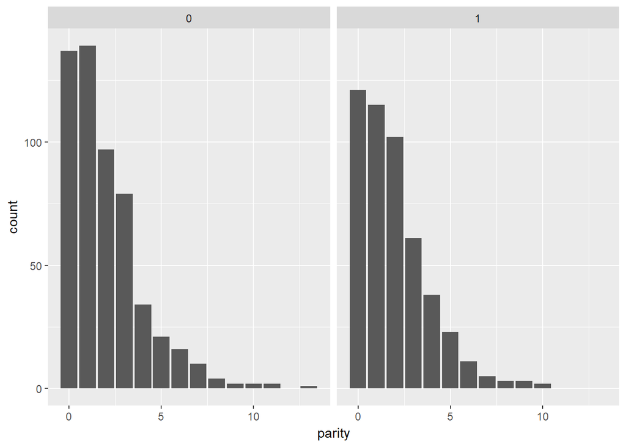

```r
ggplot(subset(babies,smoke!="NA"), mapping = aes(parity)) +
  geom_bar() +
  facet_wrap(~smoke)
```

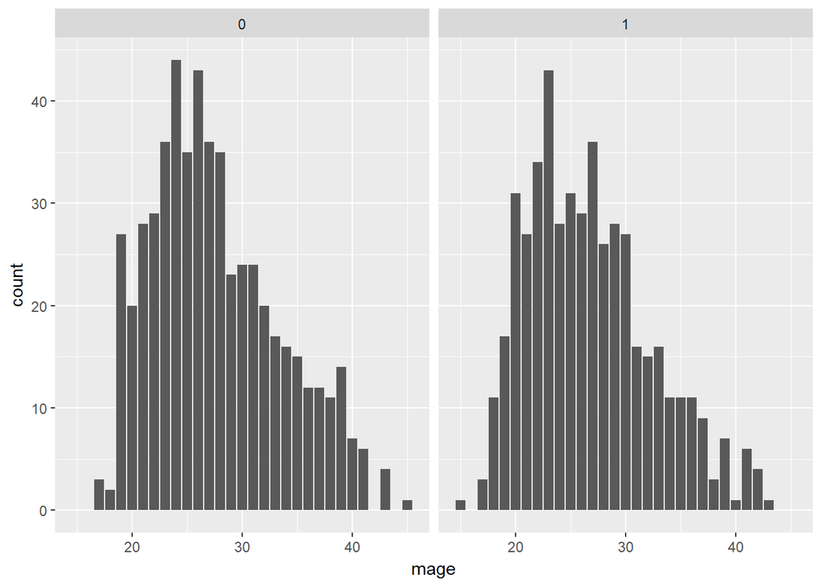

```r
ggplot(subset(babies,smoke!="NA"), mapping = aes(mage)) +
  geom_bar() +
  facet_wrap(~smoke)
```

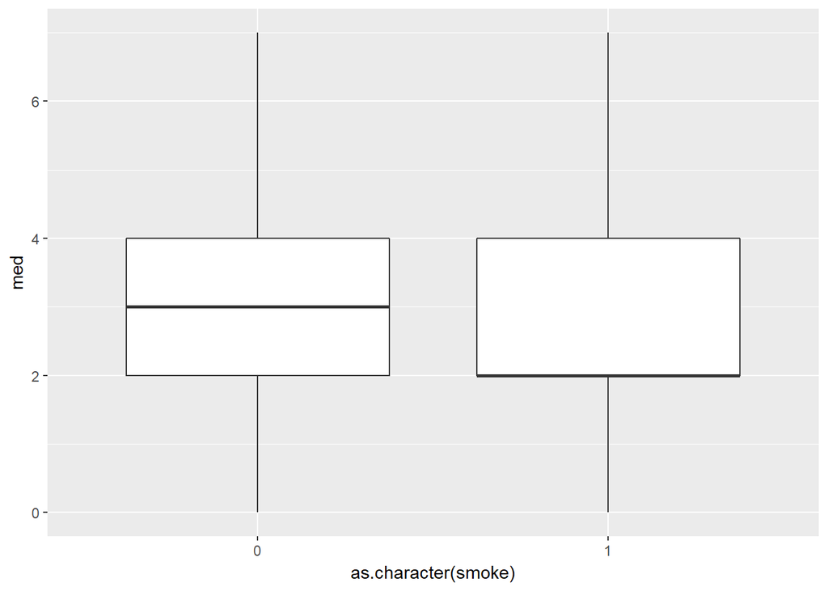

```r
ggplot(subset(babies,smoke!="NA"), mapping = aes(x=as.character(smoke), y=med)) +
  geom_boxplot()
```

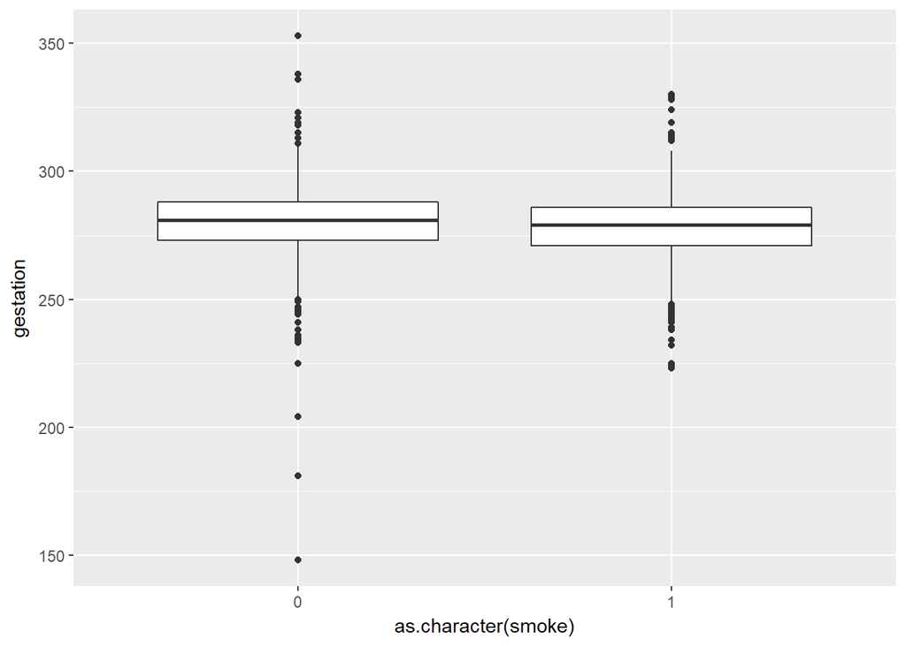

```r
ggplot(subset(babies,smoke!="NA")
       , mapping = aes(x=as.character(smoke), y=gestation)) +
  geom_boxplot()
```

The above plots investigate wether or not smoking is related to any other variable. We looked at nearly all of the variables and did not find anything interesting. We decided to inlude only the four plots above.

## Importance of the Questions:

Generally speaking, smoking is harmful to our body. But in society, a lot of people still smoke and the tendency for women to smoke during preagnancy is increasing, which may have some negative effect on next generation. Babies are significant in a family, and also important for our future, thus in order to figure out what kind of effect of smoking will lead to on both mothers and babies, we analyzed whether smoking leads to babies born prematurely and whether smoking lead to babies with low birth weight. These results will give us solid insight on smoking’s effects on babies and mothers.

## Conclusions

1. Does smoking lead to babies being born prematurely?

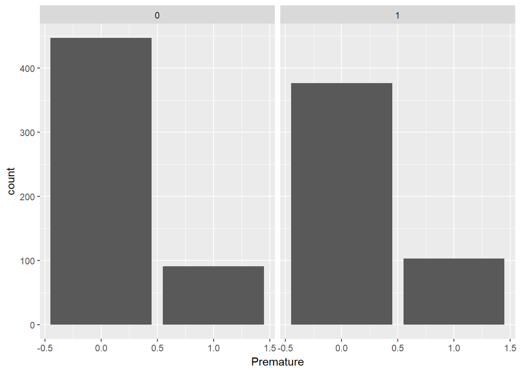

```r
ggplot(subset(babies,smoke!="NA"), mapping=aes(Premature, color=Premature)) +
  geom_bar() +
  facet_wrap(~smoke)
```

```r
NonSmokePrem <- length(which(babies$Premature==1 & babies$smoke==0))
SmokePrem <- length(which(babies$Premature==1 & babies$smoke==1))

NonSmokers <- length(which(babies$smoke==0))
Smokers <- length(which(babies$smoke==1))

RatioNonSm <- NonSmokePrem/NonSmokers
RatioSm <- SmokePrem/Smokers
```

```r
RatioNonSm
```

```
## [1] 0.1672794
```

```r
RatioSm
```

```
## [1] 0.2128099
```

Let us first consider the bar graph. If a baby is born premature, it is counted in the bars labeled “1”. If the mother smokes, the data is in the plot labeled “1”. It appears that mothers who smoke carry fewer babies to term and give birth early slightly more. We have to keep in mind that a bar graph only shows counts, so we must consider percentages.

In the sample, the group of mothers who smoke did have a greater percentage of premature births. With this data, a mother who smokes had a 21% chance of giving birth prematurely while a non-smoking mother had a 16% chance of giving birth prematurely. However, I am unsure if the difference in these values are statistically significant. In order to make this conclucion, a significance test must be preformed.

2. Does Smoking lead to Babies with Low Birth Weight?

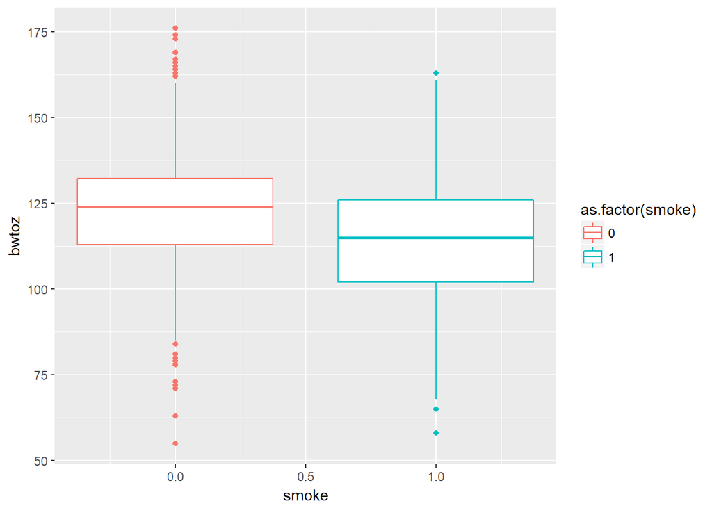

```r
ggplot(data=babies, mapping=aes(y=bwtoz, x=smoke, color=as.factor(smoke))) +
  geom_boxplot()
```

Again, it appears that the mothers who smoke give birth to children with, on average, a lower birth weight than mothers who do not smoke. Utilizing the boxplot, we know the median weight of babies born to non-smoking mothers was about 124oz, while the median weight of babies born to smoking motheres is around 115oz. We can also note that non-smoking mothers seem to have a higher change of having heavier babies. However, without a formal signififance test, we can not be certain that this relationship is significant.

# Recommendation

As stated in the conclusions of this report, there is a small relationship between smoking and premature birth as well as smoking and low birth weight. Even though the relationship is not alarmingly strong, due simply to the importance of the data, the findings still give rise to recommendations for action. These recommendations are motivated by the fact that babies born prematurely are less healthy than babies born on time, and that lightweight babies are generally less healthy than “normal” weight babies. With these facts in mind, we recommend that action is taken to inform expecting mothers of the dangers of smoking while preagnant. Specifically, we recommend that a small advertisement be placed on preagnancy tests saying “Smoking during preagnancy may cause adverse health effects for your child!”. Putting this recommendation on on preagnancy tests gets the information out to the relevant audience. The hope of this recommendation is that preagnant mothers will be more informed about the possible dangers associated with smoking during preagnancy.

# Individual Findings

## Lauren

My Question:

It may seem intuitive that the longer a baby is in the womb, the bigger that baby will be! Is the length of gestation related to a baby’s birthweight? What other factors may contribute to a baby’s birthweight?

When my sister was pregnant, she was so concerned about going past her due date, joking that she did not want the baby to be any bigger than she needed to be. This is what influences my question. I hope to have data to show my sister wether or not there is fact behind her humor.

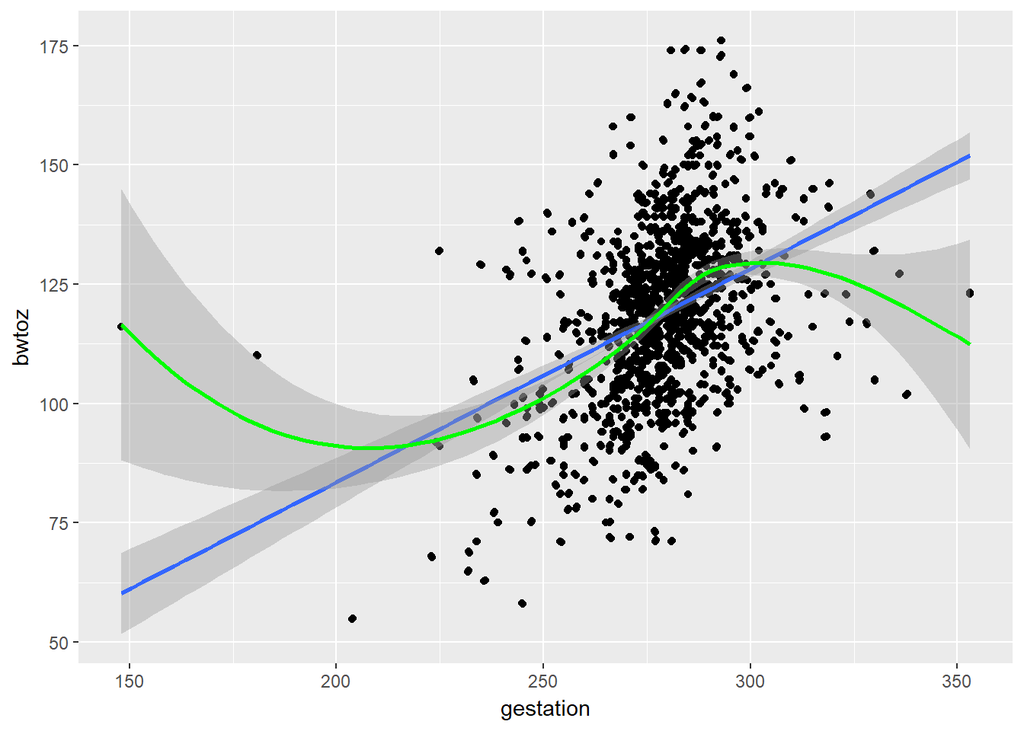

```r
ggplot(data=babies, mapping=aes(x=gestation, y=bwtoz))+
  geom_point()+
  geom_jitter() +
  geom_smooth(method="lm") +
  geom_smooth(method = "loess", color="green")
```

```r
cor(babies1$gestation, babies1$bwtoz)
```

```
## [1] 0.3925636
```

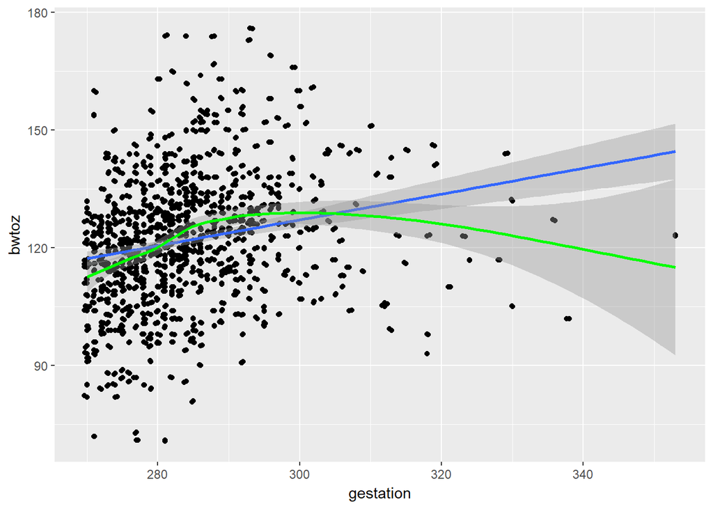

```r
df = babies[ !grepl("1", babies$Premature) , ] #getting rid of premature data

ggplot(data=df, mapping=aes(x=gestation, y=bwtoz))+
  geom_point()+
    geom_jitter()+
  geom_smooth(method="lm") +
  geom_smooth(method = "loess", color="green")
```

```r
df1 = na.omit(df)
cor(df1$gestation, df1$bwtoz)
```

```
## [1] 0.1784647
```

Ultimately, the relationship between birthweight and gestation period is pretty obvious, but other factors may play a role in a babies birthweight. Below we look at the mother’s weight and the father’s weight in comparison to the child’s birthweight.

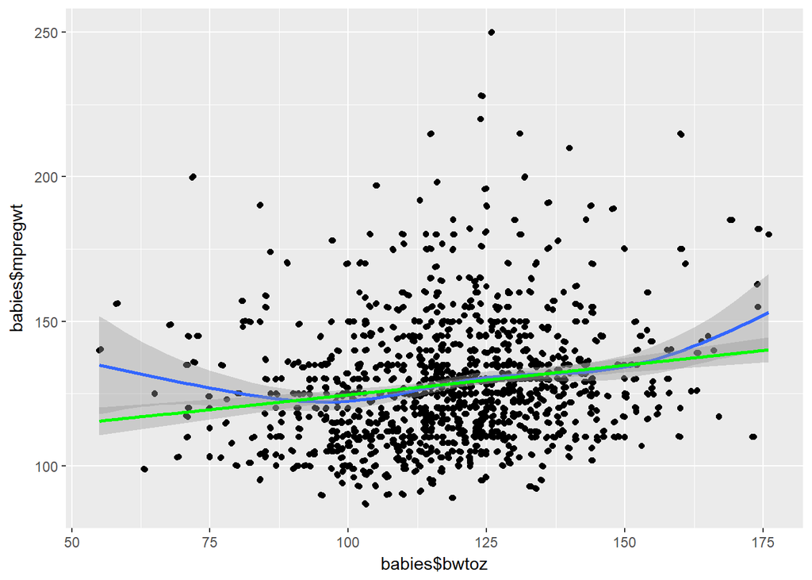

```r
ggplot(data=babies, mapping=aes(x=babies$bwtoz,y=babies$mpregwt)) +
  geom_point() +
  geom_jitter() +
  geom_smooth() +
  geom_smooth(method="lm", color="green")
```

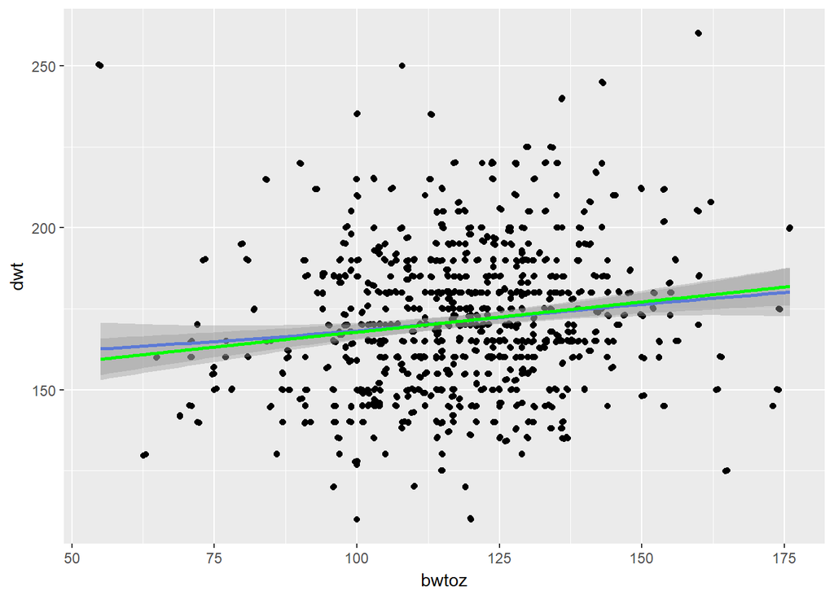

```r
ggplot(babies, aes(x=bwtoz, y=dwt)) +
  geom_point() +
  geom_jitter() +
  geom_smooth() +
  geom_smooth(method="lm", color="green")
```

```r
cor(babies1$mpregwt,babies1$bwtoz)
```

```
## [1] 0.2017992
```

```r
cor(babies1$dwt, babies1$bwtoz)
```

```
## [1] 0.140718
```

Based on the plots and the correlation coefficients, there is an extrememly weak correlation between the parents’ weight and the baby’s birthweight. In fact, this relationship is so weak that I am able to say the birthweight is not impacted by the parents weight.

To completely answer my initial question, there is a moderate correlation between length of gestation and a baby’s birthweight when I consider children born premature. However, when I consider only babies who have reached full term, the correlation coefficient changes and tells us that a baby’s weight is not correlated to the gestation period after 270 days. When I attempted to identify other influencing factors of birthweight, I considered the mother’s and father’s weight. Again, the correlation coefficient were not large enough to conclude a relationship exists.

To continue answering this question, I could compare a baby’s birthweight to other variables within our dataframe - mother’s height, father’s height, mother’s race, or number of cigarettes smoked a day. I believe that gestation period will remain the most influencing factor of a bay’s birthweight, even though the relationship does not appear to be very strong.

## Katie

My question: Does Smoking make short gestation days and premature birth, which causes light baby weight?

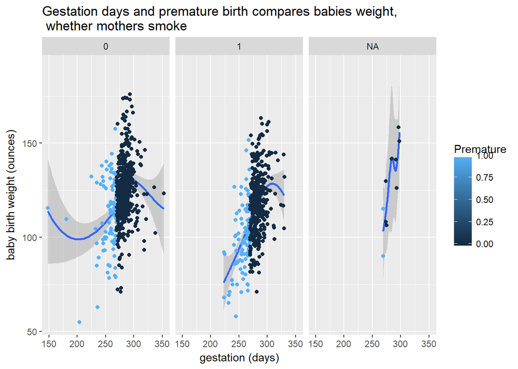

```r
ggplot(data = babies,mapping = aes(x = gestation  , y = bwtoz,color = Premature ))+
  facet_wrap(~smoke)+
  geom_smooth(method = "loess")+
  geom_jitter()+
  labs(x="gestation (days)",y = "baby birth weight (ounces)",title = "Gestation days and premature birth compares babies weight,\n whether mothers smoke")
```

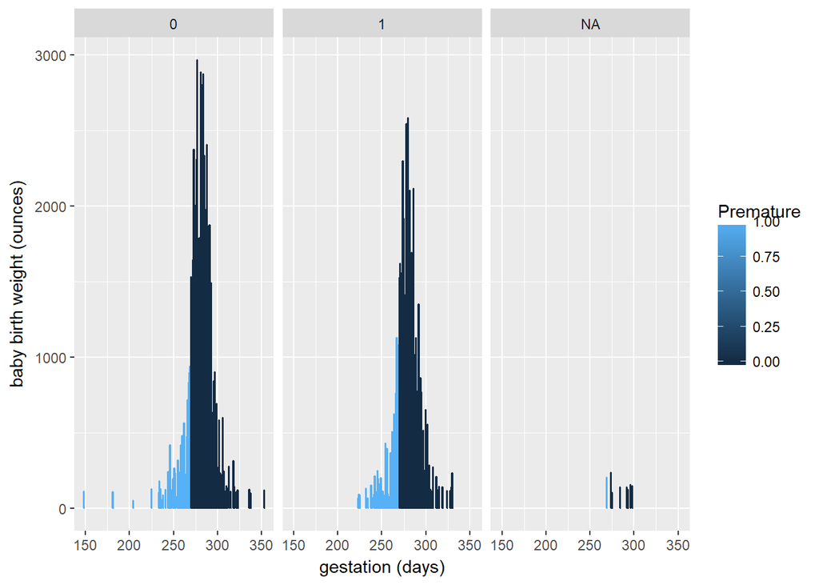

```r
ggplot(data = babies,mapping = aes(x = gestation  , y = bwtoz,color = Premature))+
  geom_col()+
  facet_wrap(~smoke)+
  labs(x="gestation (days)",y = "baby birth weight (ounces)")
```

## Chris

for this question, I was concern about the relationship between whether they smoke or not, and the influence in children’s birth weight, so I made a graph with variable(smoke and bwtoz) although we could get some information about the relationship between whether they smoke or not, but the graph are strange and seems not beautiful. but the conclusion seems when they smoke, the birth weight decrease.

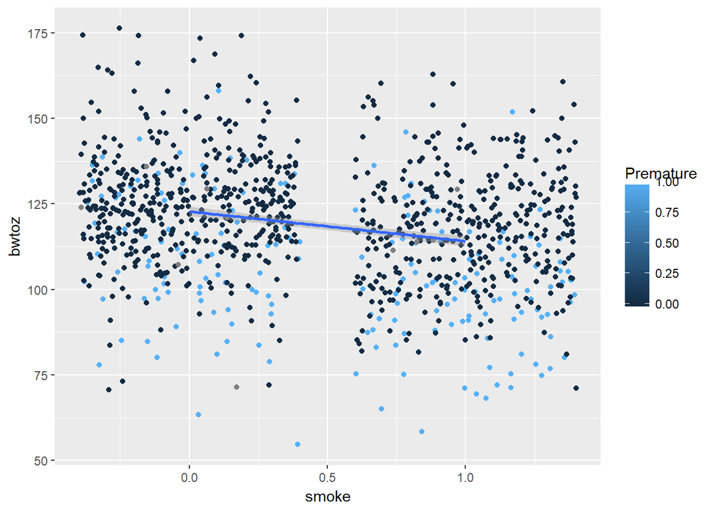

```r
ggplot(data=babies, mapping=aes(x=smoke, y=bwtoz,color=Premature))+geom_jitter()+geom_smooth(method="lm")
```

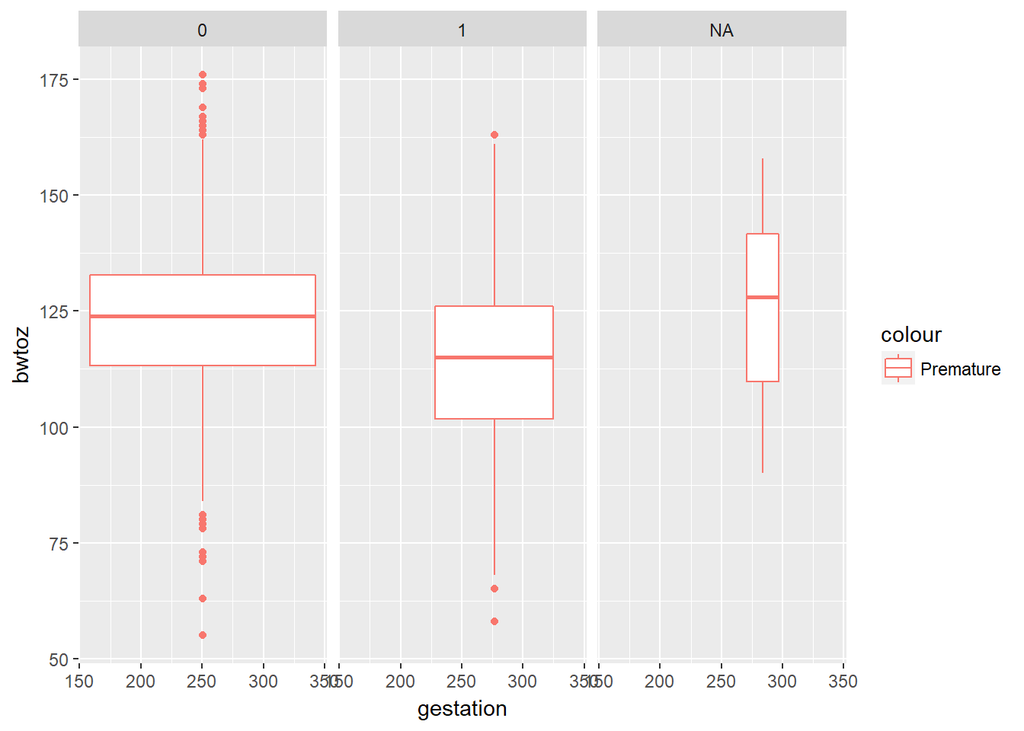

```r
ggplot(data = babies,mapping = aes(x = gestation  , y = bwtoz, color="Premature" ))+facet_wrap(~smoke)+geom_boxplot()
```

## Ryan

I thought it would be interesting to explore the question: “What is the difference between the income distributions of smokers vs. nonsmokers?” This question is imporatnt because it gives some insight on whether a person’s income has any relationship with the likleyhood that they will be a smoker. With this information, one could target specific income groups with information about the dangers of smoking, hopefully causing greater change.

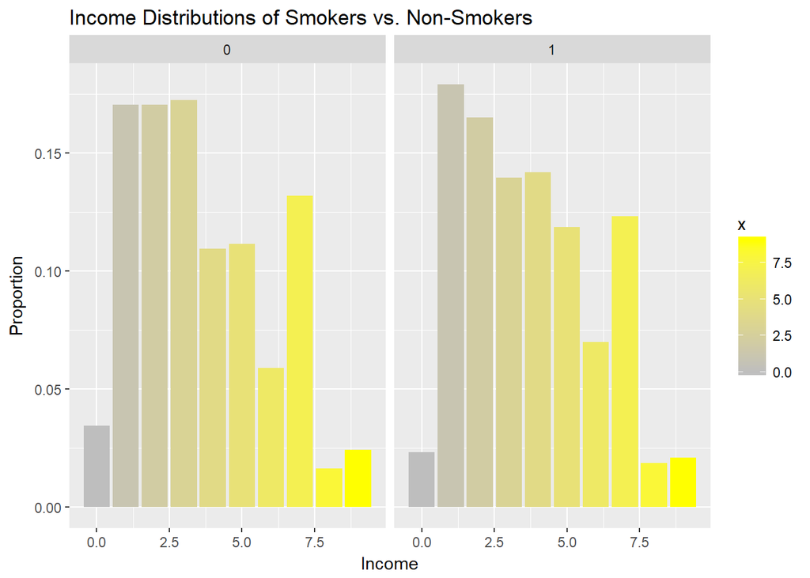

```r
ggplot(subset(babies,smoke!= "NA"),mapping = aes(x=inc))+
  geom_bar(aes(y=..prop..,fill=..x..))+scale_fill_gradient(low="gray",high="yellow")+
  facet_wrap(~smoke)+labs(x = "Income",y="Proportion",title = "Income Distributions of Smokers vs. Non-Smokers")
```

In the bar graph shown above, the income distribution for smokers is on the right and the income distribution for nonsmokers is on the left. The ‘r scale_fill_gradient’ function was used to create a color gradient, where higher income groups are represented more yellow colors, and lower income groups are represented by more gray colors. The plot also includes a label function (‘r labs()’), giving it its unique axis labels, and title. Finally, it uses the ‘r facet_wrap()’ function to separate the data into the nonsmoker/smoker subsets.

## Contributions

### Lauren

I began by creating several plots in an anttempt to answer the preliminary question. We then worked as a team to decide which were siginifcant enough to discuss. Next, I created plots to answer the two motivating questions. I wrote the explanation for these visuals. Ultimately, we were unable to determine any statistically significant relationship because we did not perform a significance test on the data. However, we did acknowledge possible correlations that may be occuring.

I continued my individual exploration by first looking at the relationship between the length of the gestation period and the babies birth weight. This question was motivated by my sister. I was surprised to find that the two variables are not strongly correlated, especially when I looked at a subset of babies who were carried to full term. I dug a little deeper in seeing if the parents’ weight has any correlation to the baby’s weight; again, I found little to no correlation existed.

### Katie

After we decided our main question, I began to think the importance of our questions, put them into words by describing the reasons and the society influence, then added to the importance part. Based on our questions, I came up with my own question which is whether the Smoking make short gestation days and premature birth, which causes light baby weight. Looking at the plot, I found there is co-relation between smoking mothers and their gestation days, but the number of mothers is not that obvious. So I plot another bar plot and compare the number of smoking mothers with their gestation days and nonsmoking mothers, which gave me good conclusion.

### Chris

I created two plot to expolred to the relationship between the “birth weight”,“premature” and “whether they smoke”, after I made two graph, I found some correlation although it against my logical thinking. But that’s the thing I got and I made my own conclusion relative to the two main question for this lab. smoke does make low birth weight. also, I fixed some grammer problem and some format problem for this team report.